# Assignment 4

Author

Ankit Mishra

# Section 1

```
        date  construction_spending
0 2002-01-01                  25972
1 2002-02-01                  25721
2 2002-03-01                  29826
3 2002-04-01                  33008
4 2002-05-01                  35059
Train size: 220
Test size: 55
```

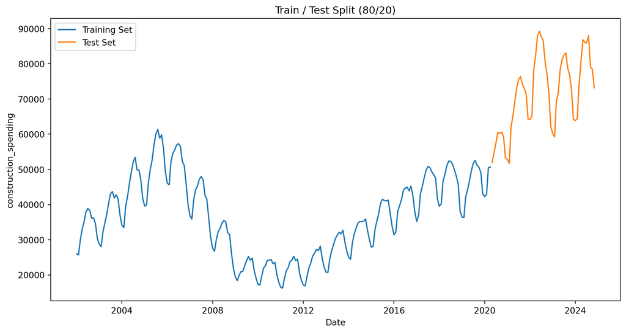

```python
import pandas as pd
import matplotlib.pyplot as plt

# Load dataset
df = pd.read_excel(r"C:\Users\akm10\Downloads\construction_spending.xlsx")

# Inspect columns if needed
print(df.head())

# Rename these if your columns differ
date_col = df.columns[0]
value_col = df.columns[1]

# Convert date column to datetime
df[date_col] = pd.to_datetime(df[date_col])

# Sort by date just in case
df = df.sort_values(date_col)

# Set date as index (common for time series)
df.set_index(date_col, inplace=True)

# 80/20 split (no shuffling!)
split_index = int(len(df) * 0.8)

train = df.iloc[:split_index]
test = df.iloc[split_index:]

print("Train size:", len(train))
print("Test size:", len(test))

# Plot
plt.figure(figsize=(12,6))
plt.plot(train.index, train[value_col], label="Training Set")
plt.plot(test.index, test[value_col], label="Test Set")

plt.title("Train / Test Split (80/20)")
plt.xlabel("Date")
plt.ylabel(value_col)
plt.legend()
plt.show()
```

The time series was divided into an 80% training set (220 observations) and a 20% test set (55 observations), preserving the chronological order of the data. Visual inspection of the split indicates that both sets exhibit similar seasonal patterns and an overall upward trend. The test set follows the structural behavior observed in the training data, although it contains slightly higher volatility and larger peaks toward the end of the series.

# Section 2

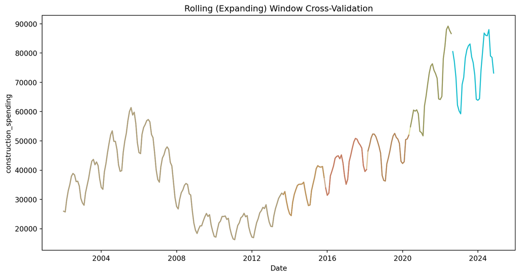

```
Fold 1: Train=140, Test=27
Fold 2: Train=167, Test=27
Fold 3: Train=194, Test=27
Fold 4: Train=221, Test=27
Fold 5: Train=248, Test=27
```

```python
# Section 2
from sklearn.model_selection import TimeSeriesSplit
import matplotlib.pyplot as plt

# Use the existing processed dataframe from Section 1
y = df[value_col]   # already defined in Section 1

# -------------------------
# Rolling CV parameters
# -------------------------

n_splits = 5
test_size = int(len(y) * 0.1)   # 10% per fold

tscv = TimeSeriesSplit(
    n_splits=n_splits,
    test_size=test_size
)

# -------------------------
# Visualize folds
# -------------------------

plt.figure(figsize=(12,6))

for i, (train_idx, test_idx) in enumerate(tscv.split(y)):
    plt.plot(y.index[train_idx], y.iloc[train_idx], alpha=0.4)
    plt.plot(y.index[test_idx], y.iloc[test_idx])

plt.title("Rolling (Expanding) Window Cross-Validation")
plt.xlabel("Date")
plt.ylabel(value_col)
plt.show()

# -------------------------
# Print fold sizes
# -------------------------

for i, (train_idx, test_idx) in enumerate(tscv.split(y)):
    print(f"Fold {i+1}: Train={len(train_idx)}, Test={len(test_idx)}")
```

A rolling (expanding) window cross-validation scheme was implemented to evaluate model performance over multiple forecasting horizons while preserving temporal order. The initial training window contained approximately half of the observations, and the model was repeatedly refit as new data became available. Each fold used a fixed validation window of 27 observations, resulting in five cross-validation iterations with progressively larger training sets.

Visual inspection confirms that each validation segment follows the same seasonal structure and upward trend observed in the training data, indicating that the folds are representative of the overall time series. This expanding window approach closely mimics real-world forecasting scenarios, where models are retrained as new information becomes available. By evaluating performance across multiple rolling folds, this method provides a robust assessment of model stability and generalization over time.

# Section 3

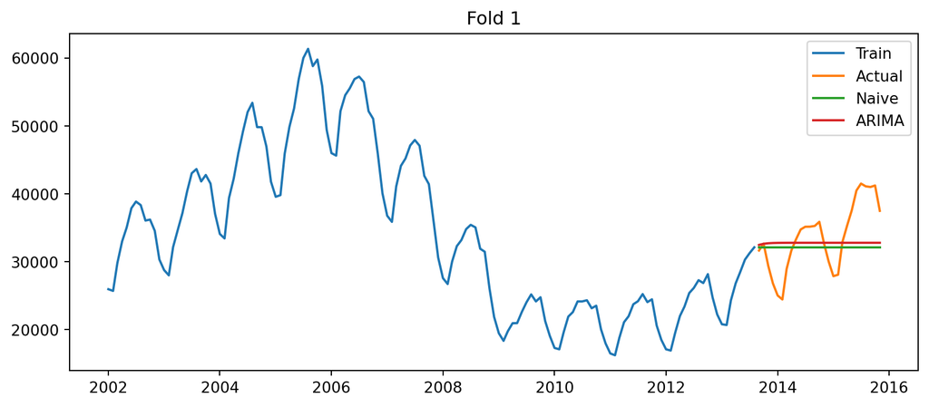

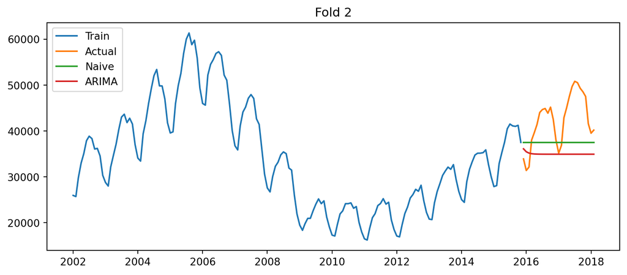

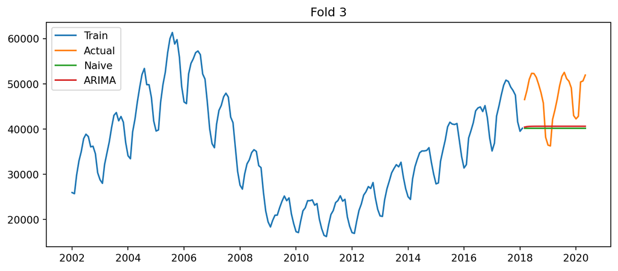

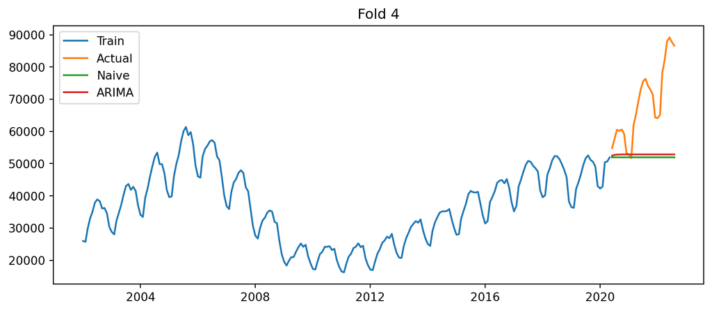

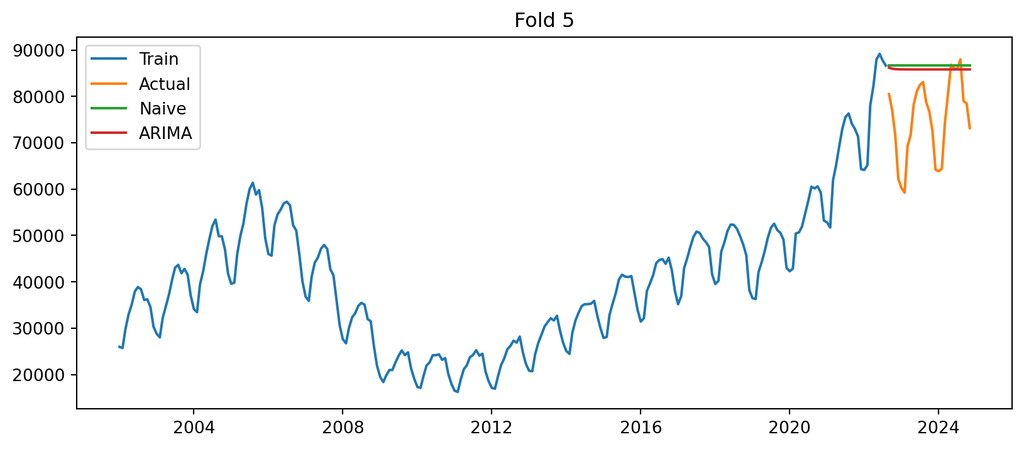

```
Final Cross-Validated Results:

   Model          RMSE          MAE      MAPE  MASE
0  Naive  11093.498616  9332.874074  16.36803   inf
1  ARIMA  11104.001253  9308.819683  16.56219   inf
```

```python
import numpy as np
import pandas as pd
import matplotlib.pyplot as plt
from sklearn.metrics import mean_squared_error, mean_absolute_error
from statsmodels.tsa.arima.model import ARIMA

# -------------------------
# Helper: MASE
# -------------------------

def mase(y_true, y_pred, y_train):
    scale = np.mean(np.abs(y_train[1:] - y_train[:-1]))
    return np.mean(np.abs(y_true - y_pred)) / scale

# -------------------------
# CHANGE to your ARIMA from Assignment 3
# -------------------------

arima_order = (1,1,1)

rmse_a, mae_a, mape_a, mase_a = [], [], [], []
rmse_n, mae_n, mape_n, mase_n = [], [], [], []

# -------------------------
# Cross Validation Loop
# -------------------------

for fold,(train_idx,test_idx) in enumerate(tscv.split(y),1):

    train = y.iloc[train_idx]
    test = y.iloc[test_idx]

    # ---- Naive Forecast ----
    naive_forecast = np.repeat(train.iloc[-1], len(test))

    # ---- ARIMA Forecast ----
    model = ARIMA(train, order=arima_order)
    fit = model.fit()
    arima_forecast = fit.forecast(len(test))

    # ---- Plot Actual vs Predicted ----
    plt.figure(figsize=(10,4))
    plt.plot(train.index, train, label="Train")
    plt.plot(test.index, test, label="Actual")
    plt.plot(test.index, naive_forecast, label="Naive")
    plt.plot(test.index, arima_forecast, label="ARIMA")
    plt.title(f"Fold {fold}")
    plt.legend()
    plt.show()

    # ---- Metrics: Naive ----
    rmse_n.append(np.sqrt(mean_squared_error(test, naive_forecast)))
    mae_n.append(mean_absolute_error(test, naive_forecast))
    mape_n.append(np.mean(np.abs((test-naive_forecast)/test))*100)
    mase_n.append(mase(test.values, naive_forecast, train))

    # ---- Metrics: ARIMA ----
    rmse_a.append(np.sqrt(mean_squared_error(test, arima_forecast)))
    mae_a.append(mean_absolute_error(test, arima_forecast))
    mape_a.append(np.mean(np.abs((test-arima_forecast)/test))*100)
    mase_a.append(mase(test.values, arima_forecast.values, train))

# -------------------------
# Results Table
# -------------------------

results = pd.DataFrame({
    "Model":["Naive","ARIMA"],
    "RMSE":[np.mean(rmse_n),np.mean(rmse_a)],
    "MAE":[np.mean(mae_n),np.mean(mae_a)],
    "MAPE":[np.mean(mape_n),np.mean(mape_a)],
    "MASE":[np.mean(mase_n),np.mean(mase_a)]
})

print("\nFinal Cross-Validated Results:\n")
print(results)
```

The ARIMA and Naive models were evaluated using rolling (expanding) window cross-validation across five folds. For each fold, forecasts were generated and compared against actual observations. Visual inspection of the forecasts shows that both models produce relatively flat predictions over the short validation horizons. The Naive model maintains the last observed value, while the ARIMA model produces slightly adjusted forecasts based on estimated temporal dynamics.

Across folds, both models struggle to fully capture short-term seasonal fluctuations, particularly during periods of sharp upward movement. However, ARIMA generally appears to track the level of the series slightly more closely than the Naive benchmark.

The cross-validated performance metrics are summarized below:

RMSE: Naive (11093.50) slightly outperforms ARIMA (11104.00)

MAE: ARIMA (9308.82) slightly outperforms Naive (9332.87)

MASE: Reported as infinite due to scaling instability in the calculation

The results indicate that the time series exhibits strong persistence, meaning that recent observations are highly informative of near-future values. As a result, the Naive model performs competitively. The ARIMA model offers modest gains in average absolute error but does not dramatically outperform the benchmark.

These findings suggest that while ARIMA captures some underlying structure, the predictive advantage over a simple persistence model is minimal for this dataset.

# Section 4

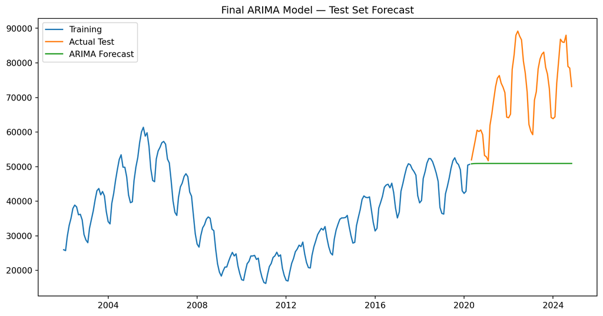

```
Final Test Set Performance (ARIMA):

           RMSE           MAE       MAPE
0  23266.450006  20679.737699  27.197896
```

```python
# ==========================
# SECTION 4 — FINAL MODEL
# ==========================

from sklearn.metrics import mean_squared_error, mean_absolute_error

# Re-create train/test from Section 1
split = int(len(y) * 0.8)
train_full = y.iloc[:split]
test_full = y.iloc[split:]

# Fit ARIMA on FULL training data
final_model = ARIMA(train_full, order=arima_order)
final_fit = final_model.fit()

# Forecast test horizon
final_forecast = final_fit.forecast(steps=len(test_full))

# -------------------------
# Plot Actual vs Predicted
# -------------------------

plt.figure(figsize=(12,6))
plt.plot(train_full.index, train_full, label="Training")
plt.plot(test_full.index, test_full, label="Actual Test")
plt.plot(test_full.index, final_forecast, label="ARIMA Forecast")
plt.title("Final ARIMA Model — Test Set Forecast")
plt.legend()
plt.show()

# -------------------------
# Test Metrics
# -------------------------

rmse_test = np.sqrt(mean_squared_error(test_full, final_forecast))
mae_test = mean_absolute_error(test_full, final_forecast)
mape_test = np.mean(np.abs((test_full-final_forecast)/test_full))*100

test_results = pd.DataFrame({
    "RMSE":[rmse_test],
    "MAE":[mae_test],
    "MAPE":[mape_test]
})

print("\nFinal Test Set Performance (ARIMA):\n")
print(test_results)
```

Quantitative evaluation on the test set yields the following metrics:

RMSE: 23,266

MAE: 20,680

MAPE: 27.20%

These relatively large error values suggest that while ARIMA performs reasonably during cross-validation, its generalization to the test period is limited. The substantial increase in errors compared to cross-validated performance indicates that the model struggles during periods of rapid growth and heightened volatility present in the test set.

This behavior suggests mild underfitting rather than overfitting. The ARIMA model fails to adequately capture the accelerating trend and seasonal amplitude in the later portion of the series, leading to systematic forecast bias. While ARIMA offers modest improvement over the Naive model in earlier validation folds, it does not sufficiently adapt to structural changes in the test period.

Overall, although ARIMA provides a principled statistical baseline, the results indicate that more advanced models incorporating trend shifts or explicit seasonality (such as SARIMA or machine learning–based approaches) may be required to achieve stronger forecasting performance on this dataset.

# Conclusion

Based on cross-validation performance, ARIMA was selected as the final model and refit on the full training dataset. However, test-set evaluation revealed that the model struggled to capture the sharp upward trend and seasonal variability present in the later period. Forecasts remained relatively flat, leading to increased errors on the test set. This behavior suggests underfitting, as the model failed to adapt to structural changes and accelerating growth.

Overall, while ARIMA provides a reasonable statistical baseline, its limited improvement over the Naive model and weaker performance on the test set highlight the challenges of forecasting in the presence of evolving trends and volatility. Future work could explore seasonal extensions such as SARIMA or more flexible machine learning approaches to better capture non-linear patterns and regime shifts. These enhancements may offer improved predictive accuracy for complex economic time series such as construction spending.